# Viscoplastic thermal convection in a 2-D square box: Tosi et al. 2015

This series of notebooks generates benchmark models from the Tosi et al. (2015) in Underworld2. The Underworld2 results are then directly compared to the results from Table 2 of Tosi et al. (2015) the paper for each case. The notebooks are broken into a general notebook for reproducing the models from scratch and 5 post-analysis notebooks which look at the results Underworld2 gives for each case after running to equilibrium.

## Case 5a: Periodic regime

Like cases 2 and 4, case 5a also assumes a viscoplastic rheology but a higher yield stress, which ultimately causes the emergence of a stable periodic regime. The parameters used for case 5a are: $Ra = 10^2$, $\Delta \eta_T = 10^5$, $\eta^* = 10^{-3}$, $\Delta \eta_z = 10$ and $\sigma_\gamma = 4$.

## References

1. Tosi, Nicola and Stein, Claudia and Noack, Lena and Hüttig, Christian and Maierová, Petra and Samuel, Henri and Davies, DR and Wilson, CR and Kramer, SC and Thieulot, Cedric and others. 2015. *A community benchmark for viscoplastic thermal convection in a 2-D square box*.

Load python functions needed for underworld. Some additional python functions from os, math and numpy used later on.

```python
%matplotlib inline
import underworld as uw
import math
from underworld import function as fn
import glucifer
import matplotlib.pyplot as pyplot
import matplotlib.pylab as pylab
import time
import numpy as np
import os
```

Set physical constants and parameters, including the Rayleigh number (*Ra*) and viscosity constants ($\eta^*$ and $\eta_T$) which are common to all Tosi et al cases.

```python
RA  = 1e2        # Rayleigh number
ETA_T = 1e5      # common viscosity constant
TS  = 0          # surface temperature
TB  = 1          # bottom boundary temperature (melting point)
ETA0 = 1e-3      # viscosity constant eta^* in Tosi et al
TMAX = 3.0
IMAX = 1000
```

Select case 5 of Tosi et al (2015) and set constants as required.

```python
CASE = 5
ETA_Y = 10.
YSTRESS = 4.
```

Set input and output file directories

```python
# input file directory
inputPath  = 'TosiInput/case' + str(CASE) + "/"
# output files
outputPath = 'TosiOutput/'
filePath   = outputPath+'files'
# make directories if they don't exist
if not os.path.isdir(outputPath):
    os.makedirs(outputPath)
if not os.path.isdir(filePath):
    os.makedirs(filePath)
```

## Create mesh and finite element variables

Set up mesh and field variables that are solved on the mesh.

```python
res = 128
mesh = uw.mesh.FeMesh_Cartesian( elementType = ("Q1/dQ0"),
                                 elementRes  = (res, res),
                                 minCoord    = (0., 0.),
                                 maxCoord    = (1., 1.))

velocityField       = uw.mesh.MeshVariable( mesh=mesh,         nodeDofCount=2 )
pressureField       = uw.mesh.MeshVariable( mesh=mesh.subMesh, nodeDofCount=1 )
temperatureField    = uw.mesh.MeshVariable( mesh=mesh,         nodeDofCount=1 )
temperatureDotField = uw.mesh.MeshVariable( mesh=mesh,         nodeDofCount=1 )
```

## Set initial conditions and boundary conditions

Load all variable fields and summary data with data from previously run cases.

```python
# load fields
temperatureField.load(    inputPath+'temperatureField.h5' )
temperatureDotField.load( inputPath+'temperatureDotField.h5' )
pressureField.load(       inputPath+'pressureField.h5')
velocityField.load(       inputPath+'velocityField.h5')

# load past iterations of summary data
data = np.loadtxt( inputPath+'Summary.txt', unpack=True )
stepsVal = data[0].tolist()
timeVal = data[1].tolist()
viscdisVal = data[2].tolist()
nu0Val = data[3].tolist()
nu1Val = data[4].tolist()
Avg_tempVal = data[5].tolist()
vrmsVal = data[6].tolist()
Rms_surfVal = data[7].tolist()
Max_vx_surfVal = data[8].tolist()
GravworkVal = data[9].tolist()
etamaxVal = data[10].tolist()
etaminVal = data[11].tolist()
```

**Conditions on the boundaries**

```python
iWalls = mesh.specialSets["MinI_VertexSet"] + mesh.specialSets["MaxI_VertexSet"]
jWalls = mesh.specialSets["MinJ_VertexSet"] + mesh.specialSets["MaxJ_VertexSet"]
freeslipBC = uw.conditions.DirichletCondition( variable      = velocityField,
                                               indexSetsPerDof = (iWalls, jWalls) )
tempBC     = uw.conditions.DirichletCondition( variable      = temperatureField,
                                               indexSetsPerDof = (jWalls,) )
```

## Set up material parameters and functions

**Viscosity field**

The viscosity is a function of temperature ($T$), the vertical coordinate ($z$) and the strain rate ($\dot{\epsilon}$) and is given by

$$ \eta(T, z, \dot{\epsilon}) = 2 \left( \frac{1}{\eta_{lin}(T,z)} + \frac{1}{\eta_{plast}(\dot{\epsilon})} \right)^{-1} $$

where the linear part is

$$ \eta_{lin}(T, z) = \exp(-\gamma_T T + \gamma_z z) $$

with $\gamma_T = \ln(\Delta \eta_T)$ and $\gamma_z = \ln(\Delta \eta_z)$. The nonlinear part is

$$ \eta_{plast}(\dot{\epsilon}) = \eta^* + \frac{\sigma_{\gamma}}{\sqrt{\dot{\epsilon} : \dot{\epsilon}}} $$

where $\eta^*$ is the effective viscosity at high stresses and $\sigma_{\gamma}$ is the yield stress. The values of $\Delta \eta_T$, $\Delta \eta_z$, $\eta^*$ and $\sigma_{\gamma}$ are assumed to be constant with values dependent on the particular case.

**Create variables required for plasticity calculations**

```python
secinv = fn.tensor.second_invariant( fn.tensor.symmetric( velocityField.fn_gradient ) )
coordinate = fn.coord()
```

**Setup viscosity functions**

Remember to use floats everywhere when setting up functions

```python
viscosityl1 = fn.math.exp(math.log(ETA_T)*-1.*temperatureField)
viscosityl2 = fn.math.exp((math.log(ETA_T)*-1.*temperatureField) + (1.-coordinate[1])*math.log(ETA_Y))

#Von Mises effective viscosity
viscosityp = ETA0 + YSTRESS/(secinv/math.sqrt(0.5)) #extra factor to account for underworld second invariant form

if CASE == 1:
    fn_viscosity = viscosityl1
elif CASE == 2:
    fn_viscosity = 2./(1./viscosityl1 + 1./viscosityp)
elif CASE == 3:
    fn_viscosity = viscosityl2
else:
    fn_viscosity = 2./(1./viscosityl2 + 1./viscosityp)
```

**Add functions for density and buoyancy**

```python
densityFn = RA*temperatureField

# define our vertical unit vector using a python tuple (this will be automatically converted to a function)
z_hat = ( 0.0, 1.0 )

# now create a buoyancy force vector using the density (FEvariable) and the vertical unit vector.
buoyancyFn = densityFn * z_hat
```

## Build the Stokes system and solvers

Setup the Stokes system with linear or nonlinear visocity viscosity depending on case.

```python
stokes = uw.systems.Stokes(velocityField=velocityField,
                              pressureField=pressureField,
                              conditions=[freeslipBC,],
                              fn_viscosity=fn.exception.SafeMaths(fn_viscosity),
                              fn_bodyforce=buoyancyFn)
```

Setup solver for the Stokes system of equations

```python
solver = uw.systems.Solver( stokes )
```

We do one solve for initial pressure and velocity with linear viscosity to get the initial strain rate invariant. This solve step also calculates a 'guess' of the the velocity field based on the linear system, which is used later in the non-linear solver.

```python
solver.solve( nonLinearIterate=False )
```

## Create an advective-diffusive system

Setup the system in underworld by flagging the temperature and velocity field variables.

```python
advDiff = uw.systems.AdvectionDiffusion( temperatureField, temperatureDotField, velocityField,
                                         fn_diffusivity=1., conditions=[tempBC,] )
```

## Metrics for benchmark

Define diagnostic functions to be used in the time loop and/or measured after reaching steady state:

- Average temperature $$ \langle T \rangle = \int^1_0 \int^1_0 T \, dxdy $$
- Top and bottom Nusselt numbers $$Nu_{top/bot} = - \left. \int^1_0 \frac{\partial T}{\partial y} \right|_{y=1/y=0} \, dx$$
- RMS velocity over the whole domain, surface and max velocity at surface $$u_{RMS} = \left( \int_0^1 \int_0^1 \left( u_x^2 + u_y^2 \right) dx dy \right)^{1/2}$$ $$u_{RMS}^{surf} = \left( \left. \int_0^1 u_x^2\right|_{y=1} dx \right)^{1/2}$$ $$u_{max}^{surf} = \left. \max(u_x)\right|_{y=1}$$
- max and min viscosity over the whole domain $$\eta_{max/min} = \max / \min \left( \eta\left(x,y\right) \right)$$
- average rate of work done against gravity $$\langle W \rangle = \int^1_0 \int^1_0 T u_y \, dx dy$$
- and the average rate of viscous dissipation $$\langle \Phi \rangle = \int^1_0 \int^1_0 \tau_{ij} \dot \epsilon_{ij} \, dx dy$$
- In steady state, if thermal energy is accurately conserved, the difference between $\langle W \rangle$ and $\langle \Phi \rangle / Ra$ must vanish, so also reported is the percentage error:

$$ \delta = \frac{\lvert \langle W \rangle - \frac{\langle \Phi \rangle}{Ra} \rvert}{max \left( \langle W \rangle, \frac{\langle \Phi \rangle}{Ra}\right)} \times 100% $$

**Setup volume integrals used in metric functions**

```python
# temperature
tempint = uw.utils.Integral( temperatureField, mesh )
# area
areaint = uw.utils.Integral( 1.,               mesh )
# velocity squared
v2int   = uw.utils.Integral(fn.math.dot(velocityField,velocityField), mesh)
# work done
dwint   = uw.utils.Integral(temperatureField*velocityField[1], mesh)
# viscous dissipation
sinner = fn.math.dot(secinv,secinv)
vdint = uw.utils.Integral((4.*fn_viscosity*sinner), mesh)
```

**Setup surface integrals used in metric functions**

```python
rmsSurfInt = uw.utils.Integral( fn=velocityField[0]*velocityField[0], mesh=mesh, integrationType='Surface',
                          surfaceIndexSet=mesh.specialSets["MaxJ_VertexSet"])
nuTop      = uw.utils.Integral( fn=temperatureField.fn_gradient[1], mesh=mesh, integrationType='Surface',
                          surfaceIndexSet=mesh.specialSets["MaxJ_VertexSet"])
nuBottom   = uw.utils.Integral( fn=temperatureField.fn_gradient[1], mesh=mesh, integrationType='Surface',
                          surfaceIndexSet=mesh.specialSets["MinJ_VertexSet"])
```

**Define diagnostic functions using integrals**

```python
def avg_temp():
    return tempint.evaluate()[0]/areaint.evaluate()[0]

def nusseltTB(temp_field, mesh):
    return -nuTop.evaluate()[0], -nuBottom.evaluate()[0]

def rms():
    return math.sqrt(v2int.evaluate()[0]/areaint.evaluate()[0])

def rms_surf():
    return math.sqrt(rmsSurfInt.evaluate()[0])

def max_vx_surf(velfield, mesh):
    vuvelxfn = fn.view.min_max(velfield[0])
    vuvelxfn.evaluate(mesh.specialSets["MaxJ_VertexSet"])
    return vuvelxfn.max_global()

def gravwork(workfn):
    return workfn.evaluate()[0]

def viscdis(vdissfn):
    return vdissfn.evaluate()[0]

def visc_extr(viscfn):
    vuviscfn = fn.view.min_max(viscfn)
    vuviscfn.evaluate(mesh)
    return vuviscfn.max_global(), vuviscfn.min_global()
```

```python
#Fields for saving data / fields

rmsField = uw.mesh.MeshVariable( mesh=mesh, nodeDofCount=1 )
rmsfn    = fn.math.sqrt( fn.math.dot( velocityField, velocityField ) )
rmsdata  = rmsfn.evaluate( mesh )
rmsField.data[:] = rmsdata

viscField = uw.mesh.MeshVariable( mesh=mesh, nodeDofCount=1 )
viscdata  = fn_viscosity.evaluate( mesh )
viscField.data[:] = viscdata

stressField = uw.mesh.MeshVariable( mesh=mesh, nodeDofCount=1)
srtdata     = fn.tensor.second_invariant( fn.tensor.symmetric( velocityField.fn_gradient ) )
rostfield   = srtdata.evaluate( mesh )
stressinv   = 2*viscdata*rostfield[:]
stressField.data[:] = stressinv
```

## Main simulation loop

Normally a loop over time increments would be added here. As we are only interested in the post-analysis a single time step will be taken to ensure that all analysis fields are live. This step will involve the non-linear Stokes system solver.

```python
steps_todo = 1
```

Initialise steps and time. Set to zero unless loading values from file.

```python
try:
    realtime = timeVal[-1]
    step = int(stepsVal[-1])
except:
    realtime = 0.0
    step = 0
steps_end = step + steps_todo
steps_output = 100
steps_output = max(steps_output,1)
print('This model has previously completed {0:6d} steps to get to time = {1:.3f}'.format(step,realtime))
```

```
This model has previously completed  77897 steps to get to time = 0.899
```

```python
# initialise timer for computation
start = time.clock()
# start loop
while step < steps_end:
    # Solve non-linear system
    solver.solve(nonLinearIterate=True)
    dt = advDiff.get_max_dt()
    if step == 0:
        dt = 0.
    # Advect using this timestep size
    advDiff.integrate(dt)
    # Increment
    realtime += dt
    step += 1
    # Calculate the Metrics, only on 1 of the processors:
    Avg_temp = avg_temp()
    Rms = rms()
    Rms_surf = rms_surf()
    Max_vx_surf = max_vx_surf(velocityField, mesh)
    Gravwork = gravwork(dwint)
    Viscdis = viscdis(vdint)
    nu1, nu0 = nusseltTB(temperatureField, mesh) # return top then bottom
    etamax, etamin = visc_extr(fn_viscosity)
    # store results
    stepsVal.append(       step)
    timeVal.append(        realtime )
    viscdisVal.append(    Viscdis )
    nu0Val.append(         nu0 )
    nu1Val.append(         nu1 )
    Avg_tempVal.append(    Avg_temp )
    vrmsVal.append(        Rms )
    Rms_surfVal.append(    Rms_surf )
    Max_vx_surfVal.append( Max_vx_surf )
    GravworkVal.append(    Gravwork )
    etamaxVal.append(      etamax )
    etaminVal.append(      etamin )

    # output fields and summary info to file (output graphics can also be added here)
    if uw.rank()==0:
        if (step % steps_output == 0) or (step == steps_end-1):
            print 'step =',step, '; CPU time =', time.clock()-start, '; vrms = ',Rms
            # Temperature
            fnametemp = "temperatureField_" + str(step).zfill(6) + ".h5"
            fullpath = os.path.join(outputPath + "files/" + fnametemp)
            temperatureField.save(fullpath)
            # Temperature time derivative
            fnametemp = "temperatureDotField_" + str(step).zfill(6) + ".h5"
            fullpath = os.path.join(outputPath + "files/" + fnametemp)
            temperatureDotField.save(fullpath)
            # Pressure
            fnametemp = "pressureField_" + str(step).zfill(6) + ".h5"
            fullpath = os.path.join(outputPath + "files/" + fnametemp)
            pressureField.save(fullpath)
            # Velocity
            fnametemp = "velocityField_" + str(step).zfill(6) + ".h5"
            fullpath = os.path.join(outputPath + "files/" + fnametemp)
            velocityField.save(fullpath)

            np.savetxt( outputPath + 'Summary.txt', np.c_[stepsVal, timeVal, viscdisVal, nu0Val,
                                                          nu1Val, Avg_tempVal, vrmsVal, Rms_surfVal,
                                                         Max_vx_surfVal, GravworkVal, etamaxVal, etaminVal],
                   header="Steps, Time, visc, Nusselt bottom/top, av_T, vrms, surf_rms, surf_max, grav, etamax, etamin" )
```

## Post-simulation analysis

Here we will calculate the quantities specified for this case in Tosi et al. (2015) and finally compare them to the values given in their Table 2.

**Period regime of case 5a**

For case 5 the convection model parameters result in a periodic regime. An example of the top and bottom Nusselt numbers as well as the RMS velocity is shown below. Other figures can be made by modifying the cells below.

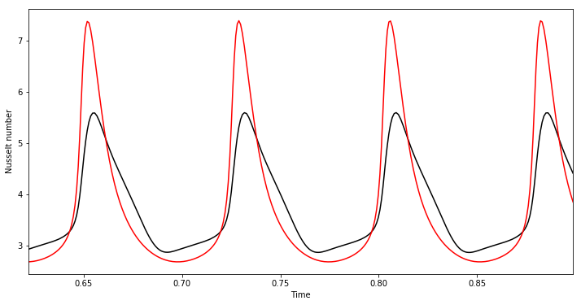

```python
pylab.rcParams[ 'figure.figsize'] = 12, 6
pyplot.plot(timeVal, nu0Val, color = 'black')
pyplot.plot(timeVal, nu1Val, color = 'red')
pyplot.xlim(timeVal[1], timeVal[-1])
pyplot.xlabel('Time')
pyplot.ylabel('Nusselt number')
pyplot.show()
```

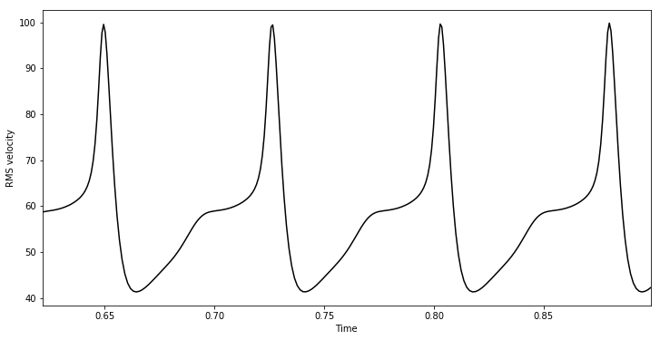

```python
pylab.rcParams[ 'figure.figsize'] = 12, 6
pyplot.plot(timeVal, vrmsVal, color = 'black')
pyplot.xlim(timeVal[1], timeVal[-1])
pyplot.xlabel('Time')
pyplot.ylabel('RMS velocity')
pyplot.show()
```

**Plot final temperature and velocity fields**

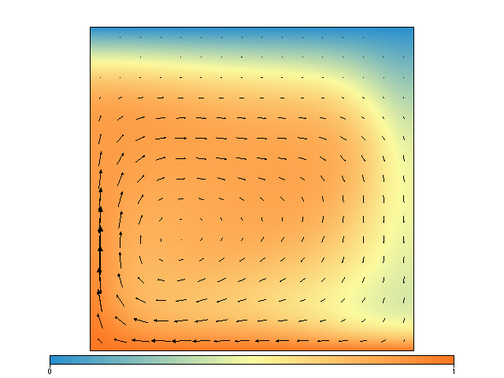

```python
velmax = np.amax(velocityField.data[:])
if(velmax==0.0): velmax = 1.0
fig1 = glucifer.Figure()
fig1.append( glucifer.objects.Surface(mesh, temperatureField) )
fig1.append( glucifer.objects.VectorArrows(mesh, velocityField/velmax, scaling=0.1, arrowHead=0.2) )
fig1.show()
```

**Calculate quantities for benchmark comparison**

```python
tempMin = np.amin(Avg_tempVal)
tempMax = np.amax(Avg_tempVal)
nuTopMin = np.amin(nu1Val)
nuTopMax = np.amax(nu1Val)
uRMSMin = np.amin(vrmsVal)
uRMSMax = np.amax(vrmsVal)
thetaMin = np.amin(GravworkVal)
thetaMax = np.amax(GravworkVal)
```

Calculate the period between maxima

```python
x = np.array(timeVal, dtype=np.float)
dx = np.gradient(vrmsVal)
# z = np.gradient(vrmsVal, dx, edge_order=2)
dx2 = np.gradient(dx)
# z = np.gradient(vrmsVal, dx2, edge_order=2)
timeZero = []
for i in range(len(timeVal)-1):
    if(dx2[i]>0) & (dx[i]*dx[i+1]<0.):
        timeZero.append(np.interp(0.0, (dx[i], dx[i+1]), (timeVal[i], timeVal[i+1])))
period = 0.0
for i in range(len(timeZero)-1):
    period += timeZero[i+1]- timeZero[i]
period = period/(len(timeZero)-1)
```

**Output all quantities**

```python
print('P         = {0:.4f}'.format(period))
print('T_min     = {0:.4f}'.format(tempMin))
print('T_max     = {0:.4f}'.format(tempMax))
print('Nu_min    = {0:.4f}'.format(nuTopMin))
print('Nu_max    = {0:.4f}'.format(nuTopMax))
print('uRMS_min  = {0:.4f}'.format(uRMSMin))
print('uRMS_max  = {0:.4f}'.format(uRMSMax))
print('theta_min = {0:.4f}'.format(thetaMin))
print('theta_max = {0:.4f}'.format(thetaMax))
```

```
P         = 0.0768
T_min     = 0.6509
T_max     = 0.6692
Nu_min    = 2.6828
Nu_max    = 7.3878
uRMS_min  = 41.3002
uRMS_max  = 99.8329
theta_min = 1.3431
theta_max = 9.5427
```

**Comparison values from Tosi et al. (2015)**

The expected benchmark values from Table 2 of Tosi et al. (2015) for case 5a are given in the table below. The minimum and maximum values from each of the participating codes are given here to provide an expected range for each quantity.

| Case 5a | $P$ | $<$$T$$>_{min}$ | $<$$T$$>_{max}$ | $Nu^{top}_{min}$ | $Nu^{top}_{max}$ | $u_{RMS}^{min}$ | $u_{RMS}^{max}$ | $<$$\theta$$>_{min}$ | $<$$\theta$$>_{max}$ |
| --- | --- | --- | --- | --- | --- | --- | --- | --- | --- |
| Min | 0.0760 | 0.6491 | 0.6671 | 2.6787 | 7.2792 | 41.2488 | 98.0040 | 1.3307 | 9.1400 |
| Max | 0.0792 | 0.6543 | 0.6722 | 2.6950 | 7.4314 | 41.9813 | 100.5380 | 1.3629 | 9.5400 |

Note that the values from the spectral code MC3D are not used to construct the min/max values here, as they are outlier values.